# Final

## Part C

```r
summary(probit13)
```

```
##
## Call:
## glm(formula = cancelled ~ dest + distance + air_time, family = binomial(link = "probit"),
##     data = flights_weather)
##
## Deviance Residuals:
##        Min          1Q      Median          3Q         Max
## -1.651e-06  -1.651e-06  -1.651e-06  -1.651e-06  -1.651e-06
##
## Coefficients:
##               Estimate Std. Error z value Pr(>|z|)
## (Intercept) -6.991e+00  3.330e+04       0        1
## destACK      2.942e-11  3.009e+04       0        1
## destALB      3.043e-11  3.095e+04       0        1
## destANC     -2.796e-11  3.851e+04       0        1
## destATL      1.933e-11  1.986e+04       0        1
## destAUS      5.640e-12  7.456e+03       0        1
## destAVL      2.246e-11  2.336e+04       0        1
## destBDL      3.091e-11  3.144e+04       0        1
## destBGR      2.617e-11  2.684e+04       0        1
## destBHM      1.735e-11  1.851e+04       0        1
## destBNA      1.931e-11  1.986e+04       0        1
## destBOS      2.957e-11  2.990e+04       0        1
## destBQN      4.438e-12  6.914e+03       0        1
## destBTV      2.822e-11  2.860e+04       0        1
## destBUF      2.765e-11  2.802e+04       0        1
## destBUR     -1.155e-11  1.302e+04       0        1
## destBWI      2.978e-11  3.015e+04       0        1
## destBZN     -1.011e-12  1.338e+04       0        1
## destCAE      2.210e-11  2.368e+04       0        1
## destCAK      2.584e-11  2.634e+04       0        1
## destCHO      2.750e-11  2.991e+04       0        1
## destCHS      2.157e-11  2.208e+04       0        1
## destCLE      2.553e-11  2.594e+04       0        1
## destCLT      2.329e-11  2.373e+04       0        1
## destCMH      2.440e-11  2.484e+04       0        1
## destCRW      2.499e-11  2.618e+04       0        1
## destCVG      2.263e-11  2.309e+04       0        1
## destDAY      2.331e-11  2.382e+04       0        1
## destDCA      2.921e-11  2.954e+04       0        1
```

[output cut: 71 more lines]

```
## destTUL      1.106e-11  1.273e+04       0        1
## destTVC      2.122e-11  2.298e+04       0        1
## destTYS      2.148e-11  2.216e+04       0        1
## destXNA      1.237e-11  1.340e+04       0        1
## distance     1.823e-14  1.812e+01       0        1
## air_time    -1.145e-15  1.093e+01       0        1
##
## (Dispersion parameter for binomial family taken to be 1)
##
##     Null deviance: 0.0000e+00  on 326400  degrees of freedom
## Residual deviance: 8.8942e-07  on 326295  degrees of freedom
##   (1174 observations deleted due to missingness)
## AIC: 212
##
## Number of Fisher Scoring iterations: 25
```

```r
summary(probit23)
```

```
##
## Call:
## glm(formula = delayed ~ dest + distance + air_time, family = binomial(link = "probit"),
##     data = flights_weather)
##
## Deviance Residuals:
##     Min       1Q   Median       3Q      Max
## -1.7684  -0.9983  -0.9097   1.3220   1.8964
##
## Coefficients:
##               Estimate Std. Error z value Pr(>|z|)
## (Intercept)  1.744e+01  5.727e-01  30.455  < 2e-16 ***
## destACK     -1.604e+01  5.179e-01 -30.971  < 2e-16 ***
## destALB     -1.607e+01  5.323e-01 -30.200  < 2e-16 ***
## destANC      1.568e+01  6.844e-01  22.904  < 2e-16 ***
## destATL     -1.052e+01  3.415e-01 -30.821  < 2e-16 ***
## destAUS     -3.058e+00  1.276e-01 -23.959  < 2e-16 ***
## destAVL     -1.230e+01  4.022e-01 -30.590  < 2e-16 ***
## destBDL     -1.645e+01  5.406e-01 -30.429  < 2e-16 ***
## destBGR     -1.400e+01  4.615e-01 -30.327  < 2e-16 ***
## destBHM     -9.108e+00  3.178e-01 -28.659  < 2e-16 ***
## destBNA     -1.038e+01  3.414e-01 -30.399  < 2e-16 ***
## destBOS     -1.608e+01  5.142e-01 -31.268  < 2e-16 ***
## destBQN     -2.408e+00  1.181e-01 -20.381  < 2e-16 ***
## destBTV     -1.519e+01  4.919e-01 -30.887  < 2e-16 ***
## destBUF     -1.493e+01  4.819e-01 -30.983  < 2e-16 ***
## destBUR      6.036e+00  2.236e-01  26.995  < 2e-16 ***
## destBWI     -1.599e+01  5.185e-01 -30.842  < 2e-16 ***
## destBZN      4.819e-01  2.279e-01   2.114 0.034513 *
## destCAE     -1.118e+01  4.081e-01 -27.400  < 2e-16 ***
## destCAK     -1.368e+01  4.529e-01 -30.198  < 2e-16 ***
## destCHO     -1.473e+01  5.140e-01 -28.659  < 2e-16 ***
## destCHS     -1.168e+01  3.797e-01 -30.748  < 2e-16 ***
## destCLE     -1.375e+01  4.461e-01 -30.828  < 2e-16 ***
## destCLT     -1.276e+01  4.080e-01 -31.277  < 2e-16 ***
## destCMH     -1.323e+01  4.272e-01 -30.970  < 2e-16 ***
## destCRW     -1.348e+01  4.502e-01 -29.947  < 2e-16 ***
## destCVG     -1.215e+01  3.971e-01 -30.592  < 2e-16 ***
## destDAY     -1.247e+01  4.096e-01 -30.445  < 2e-16 ***
## destDCA     -1.588e+01  5.080e-01 -31.248  < 2e-16 ***
```

[output cut: 73 more lines]

```
## destTYS     -1.135e+01  3.809e-01 -29.792  < 2e-16 ***
## destXNA     -7.115e+00  2.307e-01 -30.837  < 2e-16 ***
## distance    -9.693e-03  3.117e-04 -31.094  < 2e-16 ***
## air_time     5.414e-04  1.880e-04   2.879 0.003984 **
## ---
## Signif. codes:  0 '***' 0.001 '**' 0.01 '*' 0.05 '.' 0.1 ' ' 1
##
## (Dispersion parameter for binomial family taken to be 1)
##
##     Null deviance: 436637  on 326400  degrees of freedom
## Residual deviance: 431814  on 326295  degrees of freedom
##   (1174 observations deleted due to missingness)
## AIC: 432026
##
## Number of Fisher Scoring iterations: 5
```

## Part D

```r
summary(probit14)
```

```
##
## Call:
## glm(formula = cancelled ~ type + manufacturer + engines + seats +
##     engine, family = binomial(link = "probit"), data = flights_planes)
##
## Deviance Residuals:
##     Min       1Q   Median       3Q      Max
## -0.4589  -0.2416  -0.1182  -0.1030   3.4908
##
## Coefficients: (2 not defined because of singularities)
##                                             Estimate Std. Error z value
## (Intercept)                                3.927e+08  8.854e+09   0.044
## typeFixed wing single engine               9.349e-01  3.975e-01   2.352
## typeRotorcraft                            -3.927e+08  8.854e+09  -0.044
## manufacturerAIRBUS                        -3.927e+08  8.854e+09  -0.044
## manufacturerAIRBUS INDUSTRIE              -3.927e+08  8.854e+09  -0.044
## manufacturerAMERICAN AIRCRAFT INC         -3.927e+08  8.854e+09  -0.044
## manufacturerAVIAT AIRCRAFT INC            -3.927e+08  8.854e+09  -0.044
## manufacturerAVIONS MARCEL DASSAULT        -3.927e+08  8.854e+09  -0.044
## manufacturerBARKER JACK L                 -3.927e+08  8.854e+09  -0.044
## manufacturerBEECH                         -3.927e+08  8.854e+09  -0.044
## manufacturerBELL                          -5.363e-02  5.972e-01  -0.090
## manufacturerBOEING                        -3.927e+08  8.854e+09  -0.044
## manufacturerBOMBARDIER INC                -3.927e+08  8.854e+09  -0.044
## manufacturerCANADAIR                      -3.927e+08  8.854e+09  -0.044
## manufacturerCANADAIR LTD                  -3.927e+08  8.854e+09  -0.044
## manufacturerCESSNA                        -3.927e+08  8.854e+09  -0.044
## manufacturerCIRRUS DESIGN CORP            -3.927e+08  8.854e+09  -0.044
## manufacturerDEHAVILLAND                   -3.927e+08  8.854e+09  -0.044
## manufacturerDOUGLAS                       -3.927e+08  8.854e+09  -0.044
## manufacturerEMBRAER                       -3.927e+08  8.854e+09  -0.044
## manufacturerFRIEDEMANN JON                -3.927e+08  8.854e+09  -0.044
## manufacturerGULFSTREAM AEROSPACE          -3.927e+08  8.854e+09  -0.044
## manufacturerHURLEY JAMES LARRY            -3.927e+08  8.854e+09  -0.044
## manufacturerJOHN G HESS                   -3.927e+08  8.854e+09  -0.044
## manufacturerKILDALL GARY                  -3.927e+08  8.854e+09  -0.044
## manufacturerLAMBERT RICHARD               -3.927e+08  8.854e+09  -0.044
## manufacturerLEARJET INC                   -3.927e+08  8.854e+09  -0.044
## manufacturerLEBLANC GLENN T               -3.927e+08  8.854e+09  -0.044
## manufacturerMARZ BARRY                    -3.927e+08  8.854e+09  -0.044
```

[output cut: 55 more lines]

```
## engineReciprocating                         0.2854
## engineTurbo-fan                             0.3597
## engineTurbo-jet                             0.6011
## engineTurbo-prop                                NA
## engineTurbo-shaft                               NA
## ---
## Signif. codes:  0 '***' 0.001 '**' 0.01 '*' 0.05 '.' 0.1 ' ' 1
##
## (Dispersion parameter for binomial family taken to be 1)
##
##     Null deviance: 46658  on 284169  degrees of freedom
## Residual deviance: 43140  on 284128  degrees of freedom
## AIC: 43224
##
## Number of Fisher Scoring iterations: 25
```

```r
summary(probit24)
```

```
##
## Call:
## glm(formula = delayed ~ type + manufacturer + engines + seats +
##     engine, family = binomial(link = "probit"), data = flights_planes)
##
## Deviance Residuals:
##     Min       1Q   Median       3Q      Max
## -1.3183  -1.0314  -0.9353   1.3290   1.8298
##
## Coefficients: (2 not defined because of singularities)
##                                             Estimate Std. Error z value
## (Intercept)                               -5.495e+07  1.172e+09  -0.047
## typeFixed wing single engine               6.896e-02  1.931e-01   0.357
## typeRotorcraft                             5.495e+07  1.172e+09   0.047
## manufacturerAIRBUS                         5.495e+07  1.172e+09   0.047
## manufacturerAIRBUS INDUSTRIE               5.495e+07  1.172e+09   0.047
## manufacturerAMERICAN AIRCRAFT INC          5.495e+07  1.172e+09   0.047
## manufacturerAVIAT AIRCRAFT INC             5.495e+07  1.172e+09   0.047
## manufacturerAVIONS MARCEL DASSAULT         5.495e+07  1.172e+09   0.047
## manufacturerBARKER JACK L                  5.495e+07  1.172e+09   0.047
## manufacturerBEECH                          5.495e+07  1.172e+09   0.047
## manufacturerBELL                          -5.414e-01  2.921e-01  -1.854
## manufacturerBOEING                         5.495e+07  1.172e+09   0.047
## manufacturerBOMBARDIER INC                 5.495e+07  1.172e+09   0.047
## manufacturerCANADAIR                       5.495e+07  1.172e+09   0.047
## manufacturerCANADAIR LTD                   5.495e+07  1.172e+09   0.047
## manufacturerCESSNA                         5.495e+07  1.172e+09   0.047
## manufacturerCIRRUS DESIGN CORP             5.495e+07  1.172e+09   0.047
## manufacturerDEHAVILLAND                    5.495e+07  1.172e+09   0.047
## manufacturerDOUGLAS                        5.495e+07  1.172e+09   0.047
## manufacturerEMBRAER                        5.495e+07  1.172e+09   0.047
## manufacturerFRIEDEMANN JON                 5.495e+07  1.172e+09   0.047
## manufacturerGULFSTREAM AEROSPACE           5.495e+07  1.172e+09   0.047
## manufacturerHURLEY JAMES LARRY             5.495e+07  1.172e+09   0.047
## manufacturerJOHN G HESS                    5.495e+07  1.172e+09   0.047
## manufacturerKILDALL GARY                   5.495e+07  1.172e+09   0.047
## manufacturerLAMBERT RICHARD                5.495e+07  1.172e+09   0.047
## manufacturerLEARJET INC                    5.495e+07  1.172e+09   0.047
## manufacturerLEBLANC GLENN T                5.495e+07  1.172e+09   0.047
## manufacturerMARZ BARRY                     5.495e+07  1.172e+09   0.047
```

[output cut: 56 more lines]

```
## engineTurbo-fan                            0.00758 **
## engineTurbo-jet                            0.00377 **
## engineTurbo-prop                                NA
## engineTurbo-shaft                               NA
## ---
## Signif. codes:  0 '***' 0.001 '**' 0.01 '*' 0.05 '.' 0.1 ' ' 1
##
## (Dispersion parameter for binomial family taken to be 1)
##
##     Null deviance: 377493  on 279970  degrees of freedom
## Residual deviance: 375289  on 279929  degrees of freedom
##   (4199 observations deleted due to missingness)
## AIC: 375373
##
## Number of Fisher Scoring iterations: 15
```

When we run the same regression but on delays, most of the nuber go fro negative to positive. engineTurbo-fan, engineTurbo-jet and engineReciprocating are the only significant characteristics, and also some of the only negative ones, meaning there are less delays with these engines.

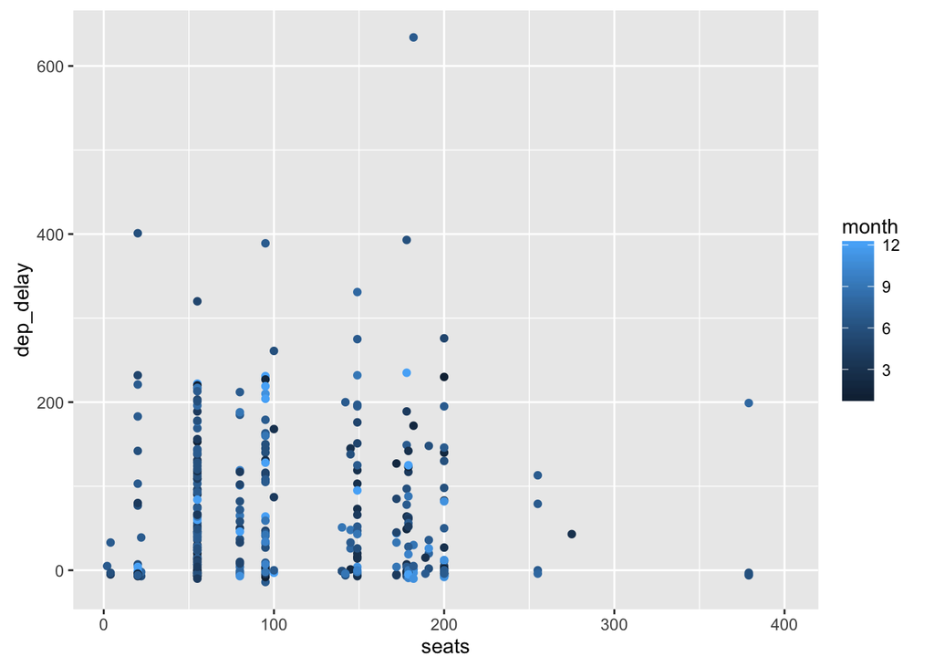

This graph shows us that planes with between 0 and 200 seats have to most delays. It might be that these planes are the most common and that is why the realtionship is what it is.

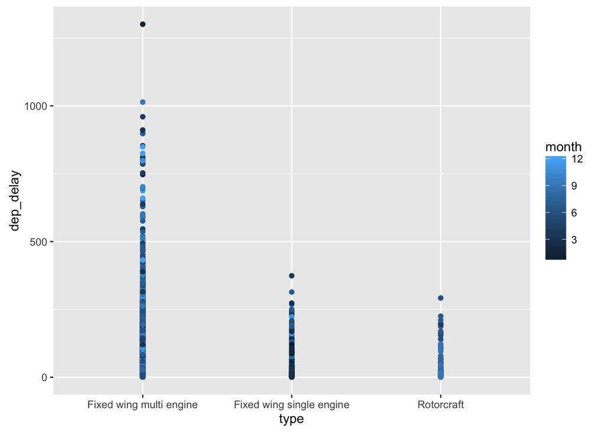

This graph shows us that fixed wing multi-engine airplanes suffer the longest delays, followed by fixed wing single-engine then rotorcraft.